# part5

Sirke

17 joulukuuta 2019

# Laskentakertojen vaikutus -analyysi

Selvitetään vaikuttaako ennustustarkkuuteen laskentakertojen lukumäärä. Saadaanko luotettavampia ennustuksia jos valitaan vain reittejä, joita on laskettu useammin (maks. 4 kertaa).

Aiemmissa analyyseissä vertailin laskentakertojen määrän vaikutusta kolmeen eri validointimetodiin (past, present ja change). Nyt teen vertailut vain metodi D:n osalta. Tarvittaessa voidaan vertailla muitakin metodeja.

## Aineisto sisään

```r
getwd()
```

```
## [1] "C:/Users/Sirke Piirainen/OneDrive - University of Helsinki/github_mallinnus/model_validation"
```

```r
localDir = "."
PredictionDir = file.path(localDir, "data")
```

```r
#model 1: data until 1999; model 2: full data
#mpred1: posterior mean based on model 1; mpred2: posterior mean based on model 2

samples = 1000
thin = 10
nChains = 4
modeltype = 1 #1 on pa-aineistolle

filename = file.path(PredictionDir, paste("predictions_",c("pa","abundance")[modeltype],
                                          "_chains_",as.character(nChains),"_thin_", as.character(thin),"_samples_", as.character(samples),
                                          ".Rdata",sep = ""))
load(filename) #mpred1, mpred2, Y, studyDesign

routes=levels(studyDesign$Route)
nr=length(routes)
years=levels(studyDesign$Year)
dim(mpred1)
```

```
## [1] 19752   120
```

```r
ns=dim(mpred1)[2]
dim(mpred2)
```

```
## [1] 19752   120
```

```r
dim(Y)
```

```
## [1] 19752   120
```

```r
dim(studyDesign)
```

```
## [1] 19752     2
```

### Periodien määrittely

```r
period1=(studyDesign$Year=="Year_1996" | studyDesign$Year=="Year_1997" | studyDesign$Year=="Year_1998" | studyDesign$Year=="Year_1999")
period2=(studyDesign$Year=="Year_2013" | studyDesign$Year=="Year_2014" | studyDesign$Year=="Year_2015" | studyDesign$Year=="Year_2016")

pm1p1=mpred1[period1,]
pm2p1=mpred2[period1,]

pm1p2=mpred1[period2,] #pm1p2 = predictions by model 1 to period 2
pm2p2=mpred2[period2,]

y1=Y[period1,]
y2=Y[period2,]

sd1 = studyDesign[period1,]
sd2 = studyDesign[period2,]

visits1 = rep(NA,nr)
visits2 = rep(NA,nr)
for (i in 1:nr){
  visits1[i] = sum(sd1$Route==routes[i])
  visits2[i] = sum(sd2$Route==routes[i])
}

ntypes=rep(NA,nr)
ntypes[visits1==0 & visits2==0]=0
ntypes[visits1>=1 & visits2==0]=0
ntypes[visits1==0 & visits2>=1]=0

ntypes[visits1==1 & visits2==1]=1

ntypes[visits1==1 & visits2>1]=2
ntypes[visits1>1 & visits2==1]=2

ntypes[visits1==2 & visits2>1]=3
ntypes[visits1>1 & visits2==2]=3

ntypes[visits1>=3 & visits2>=3]=4

#tarkistetaan kuinka monta reittiä kussakin kategoriassa on
as.data.frame(table(ntypes))
```

```
##   ntypes Freq
## 1      0 2144
## 2      1   36
## 3      2  147
## 4      3   93
## 5      4  171
```

Vuosien 96-99 ja 13-16 reittien ntype jakauma ei ole ideaali. Ainakaan jos vertaillaan kategorioita 1, 3 ja 4 (36,93 ja 171 kpl havaintoja).

### ntype 1

```r
#ntype 1
# COMPUTE MEASURES D
selroutes = routes[which(ntypes==1)]
nsr = length(selroutes)

Ap1=matrix(NA,nrow = nsr,ncol = ns)
Ay=matrix(NA,nrow = nsr,ncol = ns)
for (i in 1:nsr){
  take1 = which(sd1$Route == selroutes[i])
  take2 = which(sd2$Route == selroutes[i])
  Ap1[i,] = pm1p2[take2,]-pm1p1[take1,] #huom! ei ColSums koska vain yksi arvo, josta lasketaan
  Ay[i,] = y2[take2,]- y1[take1,]   #osassa NA:ta
}
t1 = rep(NA,ns)
for (i in 1:ns){
  t1[i] = cor(Ap1[,i],Ay[,i], use="na.or.complete")
}
```

[output not shown]

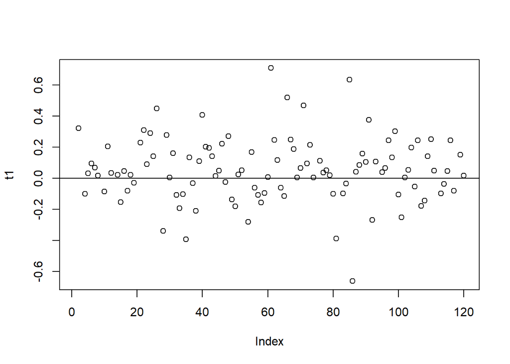

```
## integer(0)
```

```r
plot(t1) + abline(0,0)
```

```r
mean(t1,na.rm = TRUE)
```

```
## [1] 0.05687244
```

Useilla lajeilla NA:ta koska kyseessä vain kerran lasketut reitit.

### ntype 3

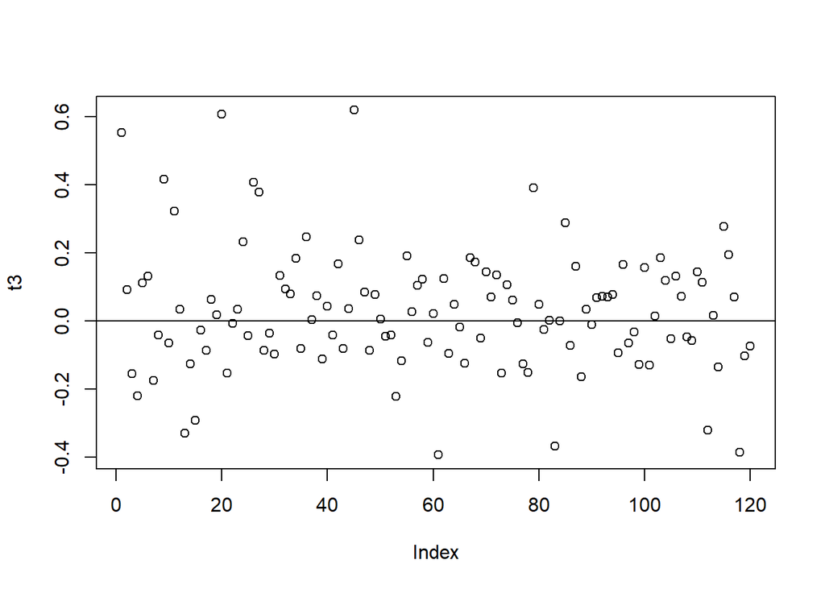

```
## integer(0)
```

```r
#ntype 3
# COMPUTE MEASURES D
selroutes = routes[which(ntypes==3)]
nsr = length(selroutes)

Ap1=matrix(NA,nrow = nsr,ncol = ns)
Ay=matrix(NA,nrow = nsr,ncol = ns)
for (i in 1:nsr){
  take1 = which(sd1$Route == selroutes[i])
  take2 = which(sd2$Route == selroutes[i])
  Ap1[i,] = colMeans(pm1p2[take2,])-colMeans(pm1p1[take1,]) #ennusteisiin ei tule NA:ta mutta seuraavissa laskuissa havaintojen NA eliminoi ennusteissa olevat virheet
  Ay[i,] = colMeans(y2[take2,])- colMeans(y1[take1,])   #Suomen vesilintujen NA:t s?ilyv?t
}
t3 = rep(NA,ns)
for (i in 1:ns){
  t3[i] = cor(Ap1[,i],Ay[,i], use="na.or.complete")
}

plot(t3) + abline(0,0)
```

```r
mean(t3,na.rm = TRUE)
```

```
## [1] 0.02984166
```

### ntype 4

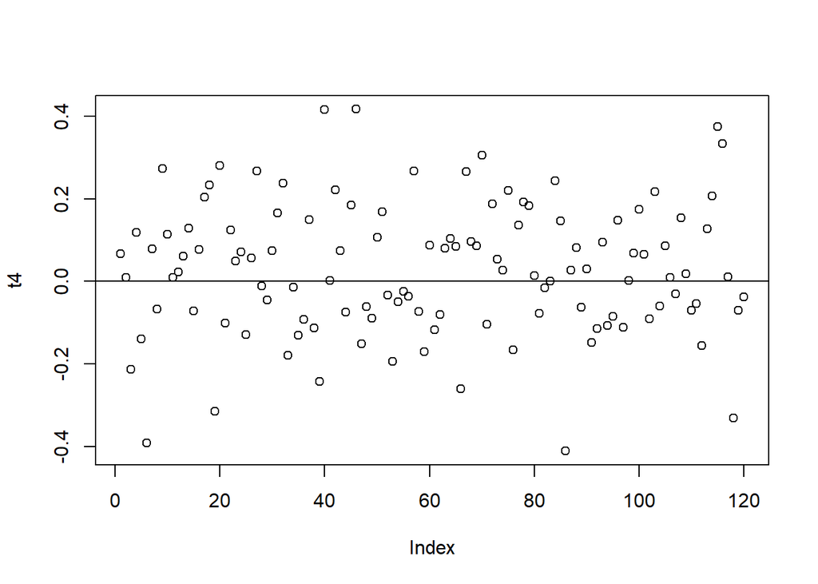

```
## integer(0)
```

```r
#ntype 4
# COMPUTE MEASURES D
selroutes = routes[which(ntypes==4)]
nsr = length(selroutes)

Ap1=matrix(NA,nrow = nsr,ncol = ns)
Ay=matrix(NA,nrow = nsr,ncol = ns)
for (i in 1:nsr){
  take1 = which(sd1$Route == selroutes[i])
  take2 = which(sd2$Route == selroutes[i])
  Ap1[i,] = colMeans(pm1p2[take2,])-colMeans(pm1p1[take1,]) #ennusteisiin ei tule NA:ta mutta seuraavissa laskuissa havaintojen NA eliminoi ennusteissa olevat virheet
  Ay[i,] = colMeans(y2[take2,])- colMeans(y1[take1,])   #Suomen vesilintujen NA:t s?ilyv?t
}
t4 = rep(NA,ns)
for (i in 1:ns){
  t4[i] = cor(Ap1[,i],Ay[,i], use="na.or.complete")
}

plot(t4) + abline(0,0)
```

```r
mean(t4,na.rm = TRUE)
```

```
## [1] 0.02919517
```

```r
#save results as datatable for further analysis
species=colnames(Y)
pa_ntype=data.frame(species,t1,t3,t4)
setnames(pa_ntype,c("t1","t3","t4"),c("pa_t1","pa_t3","pa_t4"))
write.csv(pa_ntype, "pa_ntype.csv",row.names = F)
```

## Abu-aineisto

### Aineisto

```r
modeltype = 2 #2 on abu-aineistolle

filename = file.path(PredictionDir, paste("predictions_",c("pa","abundance")[modeltype],                                    "_chains_",as.character(nChains),"_thin_", as.character(thin),"_samples_", as.character(samples),".Rdata",sep = ""))

load(filename) #mpred1, mpred2, Y, studyDesign
routes=levels(studyDesign$Route)
nr=length(routes)
years=levels(studyDesign$Year)
dim(mpred1)
```

```
## [1] 19752   120
```

```r
ns=dim(mpred1)[2]
dim(mpred2)
```

```
## [1] 19752   120
```

```r
dim(Y)
```

```
## [1] 19752   120
```

```r
dim(studyDesign)
```

```
## [1] 19752     2
```

### Periodien määrittely

```r
pm1p1=mpred1[period1,]
pm2p1=mpred2[period1,]

pm1p2=mpred1[period2,] #pm1p2 = predictions by model 1 to period 2
pm2p2=mpred2[period2,]

y1=Y[period1,]
y2=Y[period2,]

sd1 = studyDesign[period1,]
sd2 = studyDesign[period2,]
```

Abu-aineistolla on alunperin otettu mukaan reitit, joilla on käyty vähintään kaksi kertaa mutta laskut ovat edelleen voineet perustua vain yhteen havaintoon, eli kun lintuja on laskettu enemmän kuin nolla reitillä. Eli ntype-analyysin kaltainen vertailu on vaikeampaa tai sen pitäisi perustua havaintokertojen lukumäärään eikä reitin laskentakertojen lukumäärään.

Tässä nyt kuitenkin pysytään samassa tyylissä kuin pa-aineiston analyysissä ja kategorioidaan reitit sen mukaan kuinka monta kertaa se on laskettu. Havaintojen lukumäärähän voi siis olla mitä vaan.

### ntype1

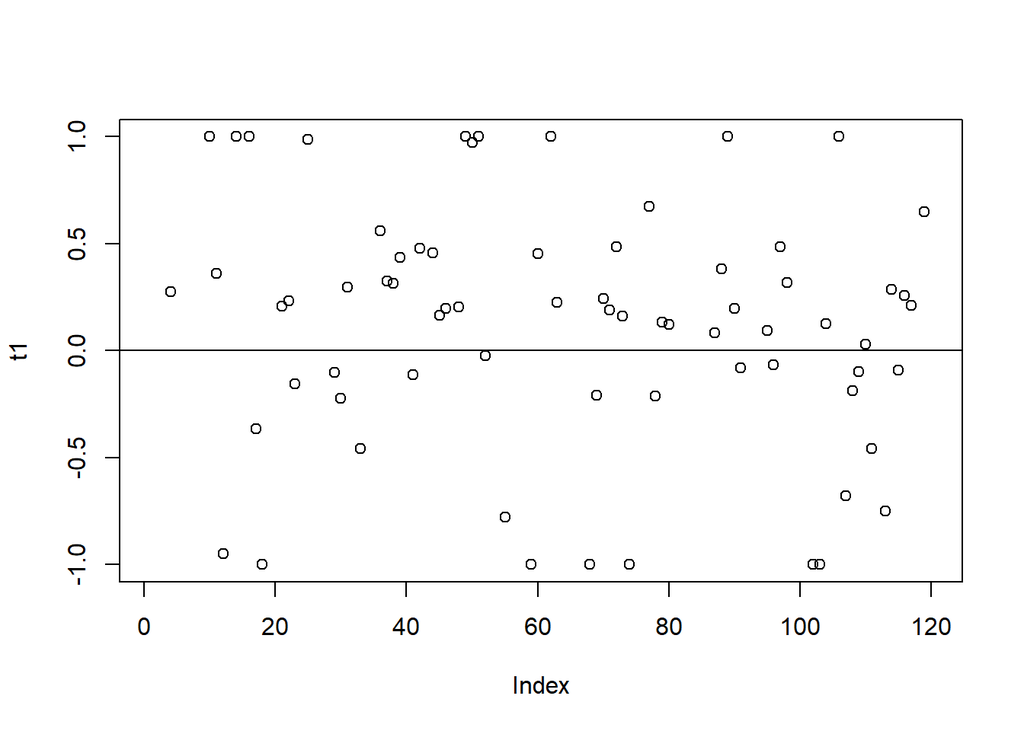

```
## integer(0)
```

```r
# COMPUTE MEASURES C AND D
selroutes = routes[which(ntypes==1)]
nsr = length(selroutes)

Ap1=matrix(NA,nrow = nsr,ncol = ns)
Ay=matrix(NA,nrow = nsr,ncol = ns)

for (j in 1:ns){
  for (i in 1:nsr){
    take1 = which(sd1$Route == selroutes[i] & y1[,j]>-1)
    take2 = which(sd2$Route == selroutes[i]& y2[,j]>-1)
    Ap1[i,j] = mean(pm1p2[take2,j])-mean(pm1p1[take1,j]) #ka laskettava vain vuosilta, jolloin lajia on havaittu
    Ay[i,j] = mean(y2[take2,j],na.rm=T)- mean(y1[take1,j],na.rm=T) #NA:t eiv?t saa est?? keskiarvon laskemista koko lajille.
  }}

t1 = rep(NA,ns)
for (i in 1:ns){
  t1[i] = cor(Ap1[,i],Ay[,i],use="na.or.complete")
}
plot(t1)+abline(0,0)
```

```r
mean(t1,na.rm = TRUE)
```

```
## [1] 0.1181881
```

### ntype3

```r
# COMPUTE MEASURES C AND D
selroutes = routes[which(ntypes==3)]
nsr = length(selroutes)

Ap1=matrix(NA,nrow = nsr,ncol = ns)
Ay=matrix(NA,nrow = nsr,ncol = ns)

for (j in 1:ns){
  for (i in 1:nsr){
    take1 = which(sd1$Route == selroutes[i] & y1[,j]>-1)
    take2 = which(sd2$Route == selroutes[i]& y2[,j]>-1)
    Ap1[i,j] = mean(pm1p2[take2,j])-mean(pm1p1[take1,j]) #ka laskettava vain vuosilta, jolloin lajia on havaittu
    Ay[i,j] = mean(y2[take2,j],na.rm=T)- mean(y1[take1,j],na.rm=T) #NA:t eiv?t saa est?? keskiarvon laskemista koko lajille.
  }}

t3 = rep(NA,ns)
for (i in 1:ns){
  t3[i] = cor(Ap1[,i],Ay[,i],use="na.or.complete")
}
```

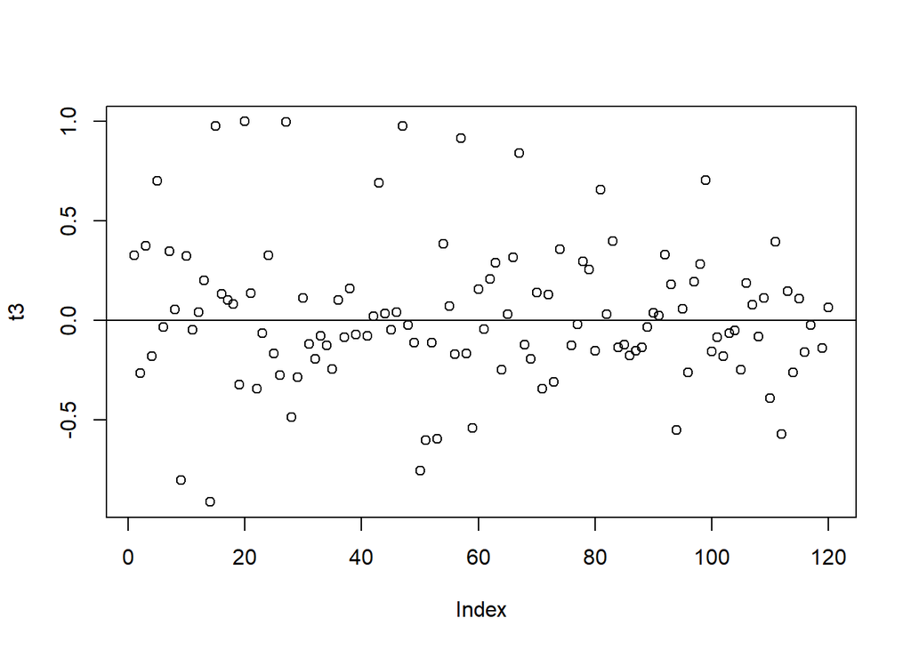

```
## integer(0)
```

```r
plot(t3)+abline(0,0)
```

```r
mean(t3,na.rm = TRUE)
```

```
## [1] 0.02407581
```

### ntype4

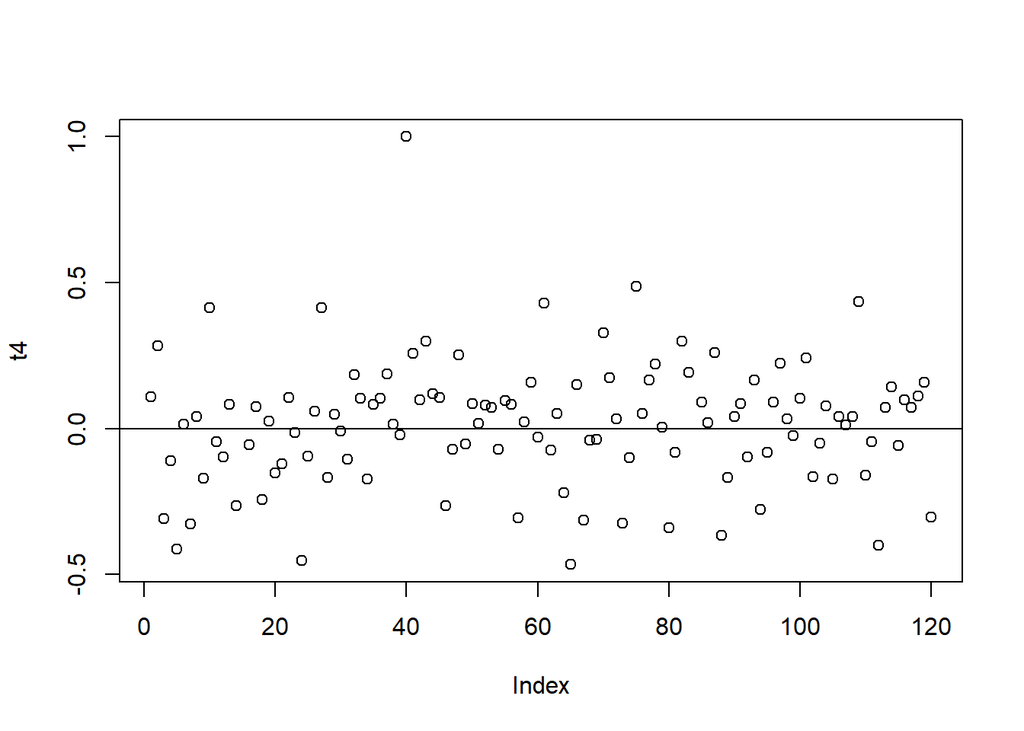

```
## integer(0)
```

```r
# COMPUTE MEASURES C AND D
selroutes = routes[which(ntypes==4)]
nsr = length(selroutes)

Ap1=matrix(NA,nrow = nsr,ncol = ns)
Ay=matrix(NA,nrow = nsr,ncol = ns)

for (j in 1:ns){
  for (i in 1:nsr){
    take1 = which(sd1$Route == selroutes[i] & y1[,j]>-1)
    take2 = which(sd2$Route == selroutes[i]& y2[,j]>-1)
    Ap1[i,j] = mean(pm1p2[take2,j])-mean(pm1p1[take1,j]) #ka laskettava vain vuosilta, jolloin lajia on havaittu
    Ay[i,j] = mean(y2[take2,j],na.rm=T)- mean(y1[take1,j],na.rm=T) #NA:t eiv?t saa est?? keskiarvon laskemista koko lajille.
  }}

t4 = rep(NA,ns)
for (i in 1:ns){
  t4[i] = cor(Ap1[,i],Ay[,i],use="na.or.complete")
}
plot(t4)+abline(0,0)
```

```r
mean(t4,na.rm = TRUE)
```

```
## [1] 0.0152518
```

```r
#save results as datatable for further analysis
species=colnames(Y)
abu_ntype=data.frame(species,t1,t3,t4)
setnames(abu_ntype,c("t1","t3","t4"),c("abu_t1","abu_t3","abu_t4"))
nres=inner_join(pa_ntype,abu_ntype,by="species")
```

## Laskentakertojen vaikutus, vertailu

### keskiarvot ja kuvaajia

```r
##lasketaan kaikille arvoille keskiarvot ja se:t
nres %>% dplyr::select(2:7)%>%colMeans(,na.rm = T)
```

```
##      pa_t1      pa_t3      pa_t4     abu_t1     abu_t3     abu_t4
## 0.05687244 0.02984166 0.02919517 0.11818812 0.02407581 0.01525180
```

```r
nres %>% dplyr::select(2:7)%>%std.error()
```

```
##      pa_t1      pa_t3      pa_t4     abu_t1     abu_t3     abu_t4
## 0.01989720 0.01644508 0.01459386 0.06778596 0.03328068 0.01982638
```

Keskiarvoissa ainakaan ei näytä olevan suuria eroja. Vaihtelu suurinta ntype1 kategorioissa.

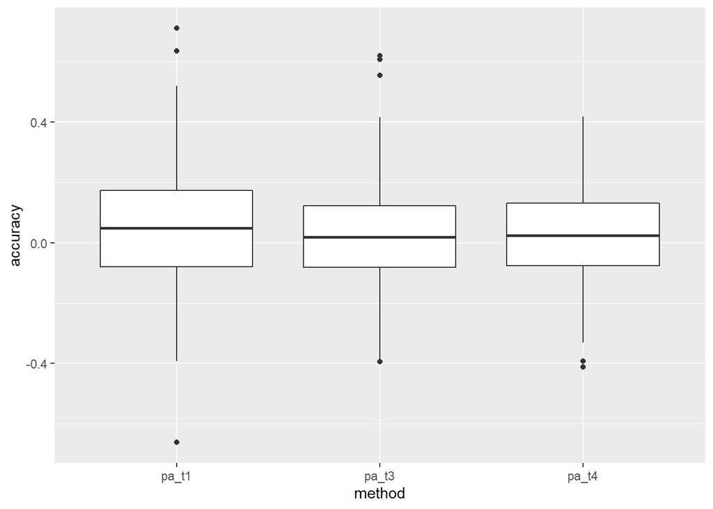

```r
#muokataan aineistoa
nres2=gather(nres,"method","accuracy",2:7)
nres2$method=as.factor(nres2$method)

#plottailua
p=ggplot(nres2,aes(x=method,y=accuracy))+geom_boxplot()
p + scale_x_discrete(limits=c("pa_t1", "pa_t3","pa_t4"))
```

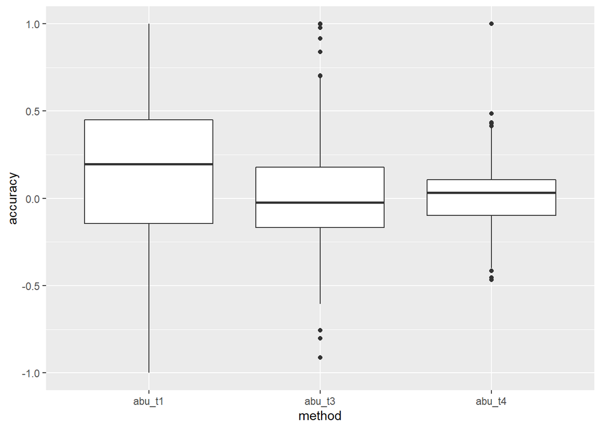

```r
p+ scale_x_discrete(limits=c("abu_t1", "abu_t3","abu_t4"))
```

Ntype 1 kategorioissa suurta vaihtelua. Ei näytä siltä, että useammin lasketut reitit antaisivat parempia ennustustarkkuuksia.

### tilastollinen testaus

#### pa

```r
#valitaan vain pa-aineisto
nres2_pa=subset(nres2,nres2$method=="pa_t1" | nres2$method == "pa_t3" | nres2$method == "pa_t4")

#two-way anova
anova(lm(nres2_pa$accuracy~nres2_pa$method+nres2_pa$species))
```

```
## Analysis of Variance Table
##
## Response: nres2_pa$accuracy
##                   Df Sum Sq  Mean Sq F value    Pr(>F)
## nres2_pa$method    2 0.0558 0.027878  1.1144    0.3299
## nres2_pa$species 119 5.8245 0.048946  1.9565 8.119e-06 ***
## Residuals        226 5.6537 0.025017
## ---
## Signif. codes:  0 '***' 0.001 '**' 0.01 '*' 0.05 '.' 0.1 ' ' 1
```

Lajit eroavat toisistaan mutta laskentakertojen määrä -metodi ei.

#### abu

```r
#valitaan vain pa-aineisto
nres2_abu=subset(nres2,nres2$method=="abu_t1" | nres2$method == "abu_t3" | nres2$method == "abu_t4")

#two-way anova
anova(lm(nres2_abu$accuracy~nres2_abu$method+nres2_abu$species))
```

```
## Analysis of Variance Table
##
## Response: nres2_abu$accuracy
##                    Df  Sum Sq Mean Sq F value Pr(>F)
## nres2_abu$method    2  0.5283 0.26416  1.8815 0.1553
## nres2_abu$species 119 16.9601 0.14252  1.0151 0.4595
## Residuals         183 25.6928 0.14040
```

Ei eroja.